# 41_keras_structured_data

Bakro

1/4/2022

## Classify structured data with feature columns

### The Dataset

We will use a small dataset provided by the Cleveland Clinic Foundation for Heart Disease. There are several hundred rows in the CSV. Each row describes a patient, and each column describes an attribute. We will use this information to predict whether a patient has heart disease, which in this dataset is a binary classification task.

Following is a description of this dataset. Notice there are both numeric and categorical columns.

[output not shown]

```r
library(keras)
library(tfdatasets)
library(tidyverse)
library(rsample)


df <- hearts
# structure of data

glimpse(df)
```

```
## Rows: 303
## Columns: 14
## $ age      <int> 63, 67, 67, 37, 41, 56, 62, 57, 63, 53, 57, 56, 56, 44, 52, 5~
## $ sex      <int> 1, 1, 1, 1, 0, 1, 0, 0, 1, 1, 1, 0, 1, 1, 1, 1, 1, 1, 0, 1, 1~
## $ cp       <int> 1, 4, 4, 3, 2, 2, 4, 4, 4, 4, 4, 2, 3, 2, 3, 3, 2, 4, 3, 2, 1~
## $ trestbps <int> 145, 160, 120, 130, 130, 120, 140, 120, 130, 140, 140, 140, 1~
## $ chol     <int> 233, 286, 229, 250, 204, 236, 268, 354, 254, 203, 192, 294, 2~
## $ fbs      <int> 1, 0, 0, 0, 0, 0, 0, 0, 0, 1, 0, 0, 1, 0, 1, 0, 0, 0, 0, 0, 0~
## $ restecg  <int> 2, 2, 2, 0, 2, 0, 2, 0, 2, 2, 0, 2, 2, 0, 0, 0, 0, 0, 0, 0, 2~
## $ thalach  <int> 150, 108, 129, 187, 172, 178, 160, 163, 147, 155, 148, 153, 1~
## $ exang    <int> 0, 1, 1, 0, 0, 0, 0, 1, 0, 1, 0, 0, 1, 0, 0, 0, 0, 0, 0, 0, 1~
## $ oldpeak  <dbl> 2.3, 1.5, 2.6, 3.5, 1.4, 0.8, 3.6, 0.6, 1.4, 3.1, 0.4, 1.3, 0~
## $ slope    <int> 3, 2, 2, 3, 1, 1, 3, 1, 2, 3, 2, 2, 2, 1, 1, 1, 3, 1, 1, 1, 2~
## $ ca       <int> 0, 3, 2, 0, 0, 0, 2, 0, 1, 0, 0, 0, 1, 0, 0, 0, 0, 0, 0, 0, 0~
## $ thal     <chr> "fixed", "normal", "reversible", "normal", "normal", "normal"~
## $ target   <int> 0, 1, 0, 0, 0, 0, 1, 0, 1, 0, 0, 0, 1, 0, 0, 0, 0, 0, 0, 0, 0~
```

## Split the dataframe into train, validation, and test

```r
# first we split between training and testing sets
split <- initial_split(df, prop = 4/5)
train <- training(split)
test <- testing(split)

# the we split the training set into validation and training
split <- initial_split(train, prop = 4/5)
train <- training(split)
val <- testing(split)

nrow(train)
```

```
## [1] 193
```

```r
nrow(val)
```

```
## [1] 49
```

```r
nrow(test)
```

```
## [1] 61
```

### Create an input pipeline using tfdatasets

Next, we will wrap the dataframes with tfdatasets. This will enable us to use feature columns as a bridge to map from the columns in the dataframe to features used to train the model. If we were working with a very large CSV file (so large that it does not fit into memory), we would use tfdatasets to read it from disk directly. That is not covered in this tutorial.

```r
df_to_dataset <- function(df, shuffle = TRUE, batch_size = 32) {
  ds <- df %>%
    tensor_slices_dataset()

  if (shuffle)
    ds <- ds %>% dataset_shuffle(buffer_size = nrow(df))

  ds %>%
    dataset_batch(batch_size = batch_size)
}
```

```r
batch_size <- 5
train_ds <- df_to_dataset(train, batch_size = batch_size)
```

```
## Loaded Tensorflow version 2.7.0
```

```r
val_ds <- df_to_dataset(val, shuffle = FALSE, batch_size = batch_size)
test_ds <- df_to_dataset(test, shuffle = FALSE, batch_size = batch_size)
```

### Understand the input pipeline

Now that we have created the input pipeline, let’s call it to see the format of the data it returns. We have used a small batch size to keep the output readable.

```r
train_ds %>%
  reticulate::as_iterator() %>%
  reticulate::iter_next() %>%
  str()
```

```
## List of 14
##  $ age     :tf.Tensor([58 53 44 64 42], shape=(5,), dtype=int32)
##  $ sex     :tf.Tensor([1 0 1 0 1], shape=(5,), dtype=int32)
##  $ cp      :tf.Tensor([4 4 3 4 3], shape=(5,), dtype=int32)
##  $ trestbps:tf.Tensor([125 130 140 130 130], shape=(5,), dtype=int32)
##  $ chol    :tf.Tensor([300 264 235 303 180], shape=(5,), dtype=int32)
##  $ fbs     :tf.Tensor([0 0 0 0 0], shape=(5,), dtype=int32)
##  $ restecg :tf.Tensor([2 2 2 0 0], shape=(5,), dtype=int32)
##  $ thalach :tf.Tensor([171 143 180 122 150], shape=(5,), dtype=int32)
##  $ exang   :tf.Tensor([0 0 0 0 0], shape=(5,), dtype=int32)
##  $ oldpeak :tf.Tensor([0.  0.4 0.  2.  0. ], shape=(5,), dtype=float32)
##  $ slope   :tf.Tensor([1 2 1 2 1], shape=(5,), dtype=int32)
##  $ ca      :tf.Tensor([2 0 0 2 0], shape=(5,), dtype=int32)
##  $ thal    :tf.Tensor([b'reversible' b'normal' b'normal' b'normal' b'normal'], shape=(5,), dtype=string)
##  $ target  :tf.Tensor([0 0 0 0 0], shape=(5,), dtype=int32)
```

### Create the feature spec

```r
# We want to train a model to predict the target variable using Keras but, before that we need to prepare the data. We need to transform the categorical variables into some form of dense variable, we usually want to normalize all numeric columns too.
#
# The feature spec interface works with data.frames or TensorFlow datasets objects.
#
# Let’s start creating our feature specification
spec <- feature_spec(train_ds, target ~ .)

# The first thing we need to do after creating the feature_spec is decide on the variables’ types.
#
# We can do this by adding steps to the spec object.

spec <- spec %>%
  step_numeric_column(
    all_numeric(), -cp, -restecg, -exang, -sex, -fbs,
    normalizer_fn = scaler_standard()
  ) %>%
  step_categorical_column_with_vocabulary_list(thal)
```

When using step_categorical_column_with_vocabulary_list you can also provide a vocabulary argument with the fixed vocabulary. The recipe will find all the unique values in the dataset and use it as the vocabulary.

You can also specify a normalizer_fn to the step_numeric_column. In this case the variable will be transformed by the feature column. Note that the transformation will occur in the TensorFlow Graph, so it must use only TensorFlow ops. Like in the example we offer pre-made normalizers - and they will compute the normalizing function during the recipe preparation.

You can also use selectors like:

starts_with(), ends_with(), matches() etc. (from tidyselect)

all_numeric() to select all numeric variables

all_nominal() to select all strings

has_type(“float32”) to select based on TensorFlow variable type.

```r
# Now we can print the recipe:

spec
```

[output not shown]

```r
# After specifying the types of the columns you can add transformation steps. For example you may want to bucketize a numeric column:
spec <- spec %>%
  step_bucketized_column(age, boundaries = c(18, 25, 30, 35, 40, 45, 50, 55, 60, 65))
```

```r
# You can also specify the kind of numeric representation that you want to use for your categorical variables.
spec <- spec %>%
  step_indicator_column(thal) %>%
  step_embedding_column(thal, dimension = 2)

# Another common transformation is to add interactions between variables using crossed columns.

spec <- spec %>%
  step_crossed_column(thal_and_age = c(thal, bucketized_age), hash_bucket_size = 1000) %>%
  step_indicator_column(thal_and_age)

# Note that the crossed_column is a categorical column, so we need to also specify what kind of numeric tranformation we want to use. Also note that we can name the transformed variables - each step uses a default naming for columns, eg. bucketized_age is the default name when you use step_bucketized_column with column called age.
```

```r
# With the above code we have created our recipe. Note we can also define the recipe by chaining a sequence of methods:

spec <- feature_spec(train_ds, target ~ .) %>%
  step_numeric_column(
    all_numeric(), -cp, -restecg, -exang, -sex, -fbs,
    normalizer_fn = scaler_standard()
  ) %>%
  step_categorical_column_with_vocabulary_list(thal) %>%
  step_bucketized_column(age, boundaries = c(18, 25, 30, 35, 40, 45, 50, 55, 60, 65)) %>%
  step_indicator_column(thal) %>%
  step_embedding_column(thal, dimension = 2) %>%
  step_crossed_column(c(thal, bucketized_age), hash_bucket_size = 10) %>%
  step_indicator_column(crossed_thal_bucketized_age)
```

After defining the recipe we need to `fit` it. It’s when fitting that we compute the vocabulary list for categorical variables or find the mean and standard deviation for the normalizing functions. Fitting involves evaluating the full dataset, so if you have provided the vocabulary list and your columns are already normalized you can skip the fitting step (TODO).

In our case, we will fit the feature spec, since we didn’t specify the vocabulary list for the categorical variables

```r
spec_prep <- fit(spec)

# After preparing we can see the list of dense features that were defined:

str(spec_prep$dense_features())
```

```
## List of 11
##  $ age                                  :NumericColumn(key='age', shape=(1,), default_value=None, dtype=tf.float32, normalizer_fn=<function make_python_function.<locals>.python_function at 0x000000003E83B940>)
##  $ trestbps                             :NumericColumn(key='trestbps', shape=(1,), default_value=None, dtype=tf.float32, normalizer_fn=<function make_python_function.<locals>.python_function at 0x000000003E83BA60>)
##  $ chol                                 :NumericColumn(key='chol', shape=(1,), default_value=None, dtype=tf.float32, normalizer_fn=<function make_python_function.<locals>.python_function at 0x000000003E90F670>)
##  $ thalach                              :NumericColumn(key='thalach', shape=(1,), default_value=None, dtype=tf.float32, normalizer_fn=<function make_python_function.<locals>.python_function at 0x000000003E90FA60>)
##  $ oldpeak                              :NumericColumn(key='oldpeak', shape=(1,), default_value=None, dtype=tf.float32, normalizer_fn=<function make_python_function.<locals>.python_function at 0x000000003E90F040>)
##  $ slope                                :NumericColumn(key='slope', shape=(1,), default_value=None, dtype=tf.float32, normalizer_fn=<function make_python_function.<locals>.python_function at 0x000000003E90F9D0>)
##  $ ca                                   :NumericColumn(key='ca', shape=(1,), default_value=None, dtype=tf.float32, normalizer_fn=<function make_python_function.<locals>.python_function at 0x000000003E90F3A0>)
##  $ bucketized_age                       :BucketizedColumn(source_column=NumericColumn(key='age', shape=(1,), default_value=None, dtype=tf.float32, normalizer_fn=<function make_python_function.<locals>.python_function at 0x000000003E83B940>), boundaries=(18.0, 25.0, 30.0, 35.0, 40.0, 45.0, 50.0, 5…
##  $ indicator_thal                       :IndicatorColumn(categorical_column=VocabularyListCategoricalColumn(key='thal', vocabulary_list=('1', '2', 'fixed', 'normal', 'reversible'), dtype=tf.string, default_value=-1, num_oov_buckets=0))
##  $ embedding_thal                       :EmbeddingColumn(categorical_column=VocabularyListCategoricalColumn(key='thal', vocabulary_list=('1', '2', 'fixed', 'normal', 'reversible'), dtype=tf.string, default_value=-1, num_oov_buckets=0), dimension=2, combiner='mean', initializer=<tensorflow.python.…
##  $ indicator_crossed_thal_bucketized_age:IndicatorColumn(categorical_column=CrossedColumn(keys=(VocabularyListCategoricalColumn(key='thal', vocabulary_list=('1', '2', 'fixed', 'normal', 'reversible'), dtype=tf.string, default_value=-1, num_oov_buckets=0), BucketizedColumn(source_column=NumericCol…
```

## Build the model

Now we are ready to define our model in Keras. We will use a specialized `layer_dense_features` that knows what to do with the feature columns specification.

```r
model <- keras_model_sequential() %>%
  layer_dense_features(dense_features(spec_prep)) %>%
  layer_dense(units = 32, activation = "relu") %>%
  layer_dense(units = 1, activation = "sigmoid")


model %>% compile(
  loss = loss_binary_crossentropy,
  optimizer = "adam",
  metrics = "binary_accuracy"
)
```

## Train the model

We can finally train the model on the dataset:

```r
history <- model %>%
  fit(
    dataset_use_spec(train_ds, spec = spec_prep),
    epochs = 15,
    validation_data = dataset_use_spec(val_ds, spec_prep),
    verbose = 2
  )
```

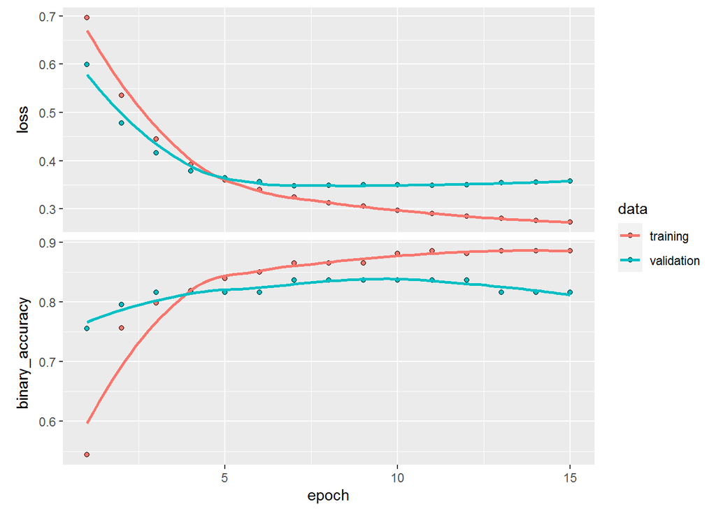

```r
plot(history)
```

```r
pred <- predict(model, test)
Metrics::auc(test$target, pred)
```

```
## [1] 0.872093
```